# Predictors of Chronic Juvenile Delinquency

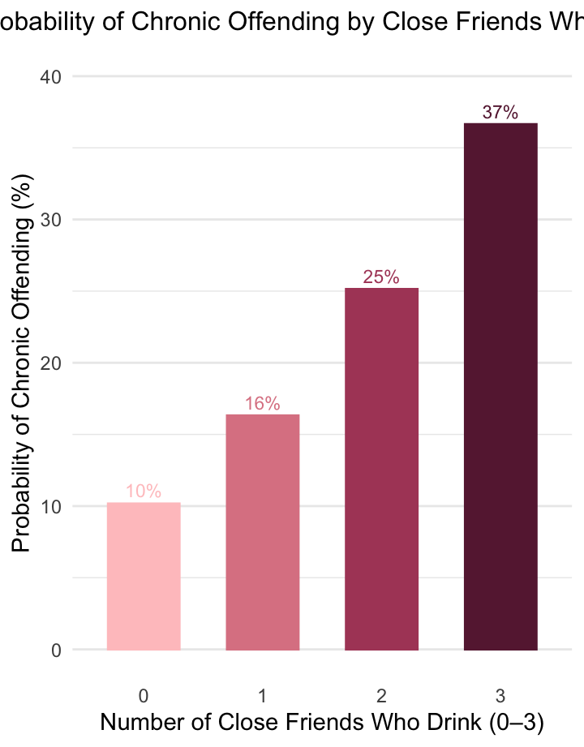

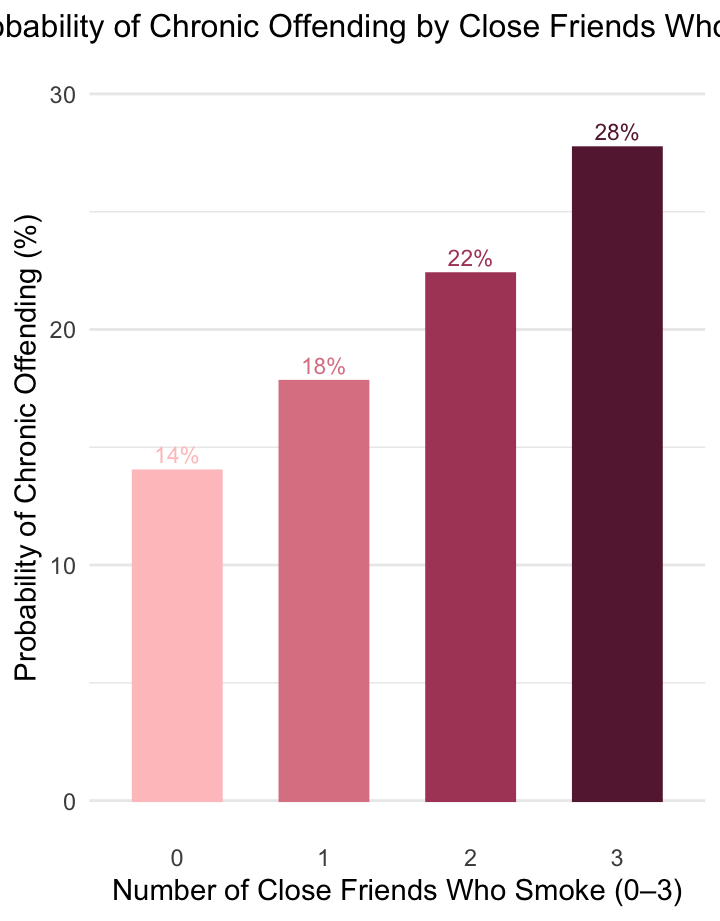

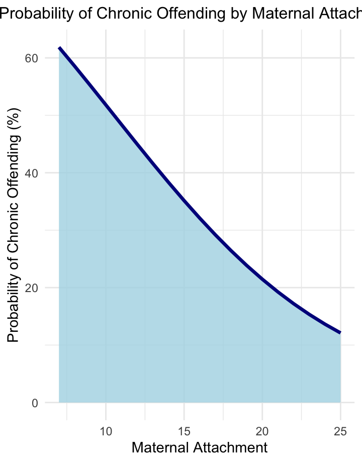

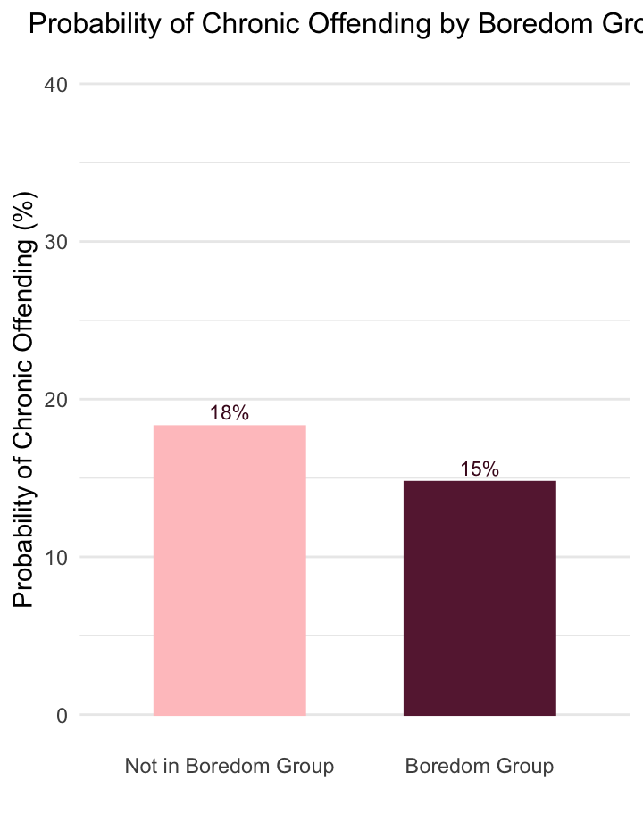

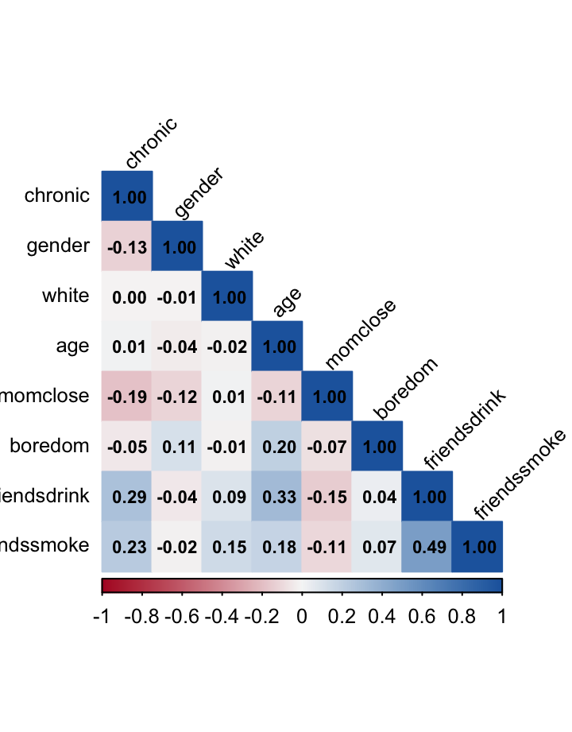

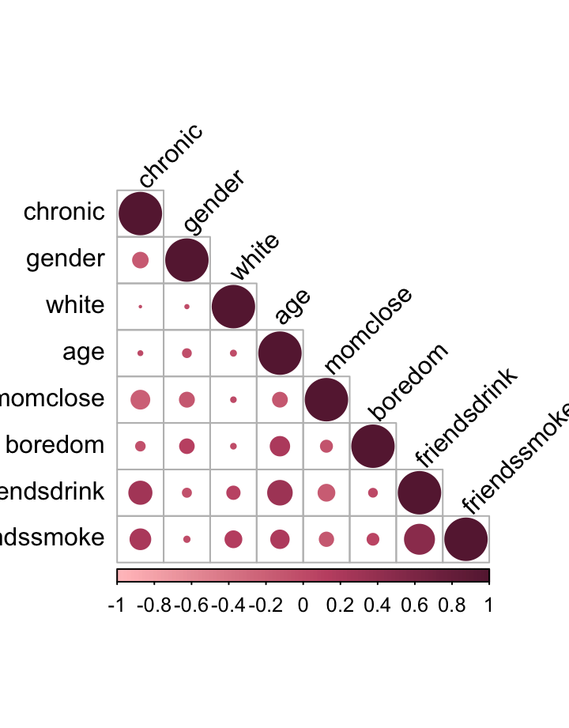

# Overview

### **Topic of Interest, Hypotheses, and Intended Audience**

**Topic of Interest**

- Research Question: How do maternal attachment, exposure to deviant peers, and boredom relate to chronic juvenile offending?
- This question is important as chronic offenders represent a small but high-risk subgroup of adolescents who experience poorer educational, social, and health outcomes in adulthood.

**Hypotheses**

Based on key theories in juvenile delinquency, the project predicts:

- Greater exposure to peers who engage in risky behaviors (drinking and smoking) will significantly increase the likelihood of chronic offending (Peer Influence Theory).
- Lower maternal attachment will be associated with a higher probability of chronic offending (Control Theory).
- Boredom will be positively associated with chronic offending (Strain Theory).

**Intended Audience**

- Community health workers
- Juvenile justice professionals
- Social science and public health students
- Assumes an basic level of statistical knowledge

### **Prior Research & Project Improvement**

The original version of this project was an academic research paper I had written for a Juvenile Delinquency course at the University of Portland. It included strong theoretical backing and statistical analysis, but relied largely on tables and raw regression coefficients. While appropriate for the assignment at the time, this format may not be clear or engaging to a larger audience. I wanted to revise my past project by:

- Transforming the written paper into a more visual narrative.
- Replacing static tables with plots, specifically predicted probability graphs and correlation heatmaps.
- Recreating the statistical models in R rather than in SPSS/Excel.

### **Dataset**

This project uses data from Wave I of the National Longitudinal Study of Adolescent to Adult Health (Add Health), which was collected between 1994 and 1995. [Add Health](https://addhealth.cpc.unc.edu/documentation/study-design/) is a nationally representative study of U.S. adolescents in grades 7–12 and includes detailed information on family relationships, peer groups, health behaviors, and social environments. It is particularly well suited for studying patterns of juvenile delinquency.

The Wave I survey originally included 20,745 adolescents. For my initial research at the University of Portland, students were provided a reduced working file of Wave I data containing 3,217 observations. After limiting the dataset to complete cases in this project, the final sample includes 2,895 adolescents.

# Data & Methods

### **Sample and Key Variables**

The analysis focuses on a set of variables drawn from Wave I in-home survey data that capture key theories discussed in my research:

**Chronic Offender Variable**

- A binary indicator identifying adolescents in the top 20 percent of the delinquency distribution.
- Values are coded as 0 = not a chronic offender and 1 = chronic offender.

**Control Variable**

- A measure of attachment/closeness to a maternal figure.
- Values range from 5 to 25, where lower values indicate weaker attachment and higher values indicate stronger attachment.

**Peer Influence Variables**

- Two peer variables were created: number of close friends who drink alcohol and number of close friends who smoke cigarettes (0 = No Friends, 3 = 3 Friends).

**Strain Variable**

- Captured through a hobby engagement measure (1 = Bored, 0 = Not Bored).
- Adolescents in the lowest 10 percent of hobby engagement were flagged to reflect higher levels of boredom (strain).

**Demographic Controls**

- Age (values range from 11 to 21 in years)
- Gender (1 = Male, 2 = Female)
- Race (1 = White, 0 = Not White)

### **Variable Preparation & Methods**

The data for this project came directly from the original working Add Health (.sav) file used in the SPSS-based analysis for my initial project. The key measures were already constructed and recoded, so data preparation focused mainly on cleaning and organizing the dataset for use in R and for visualization.

To generate the predicted probability plots shown later in the dashboard, I reran a binary logistic regression model in R, which is appropriate because chronic offending is coded as a binary outcome. These model results were then passed into the ggpredict() function, which calculates predicted probabilities for key variables while holding all other variables constant at their mean values. This allowed visualizations to show how each factor changes the likelihood of chronic offending. I also created a correlation matrix using the selected variables and visualized it with the corrplot package to show the strength and direction of relationships among key predictors.

# Peer Influence

### **Friends Who Drink Plot**

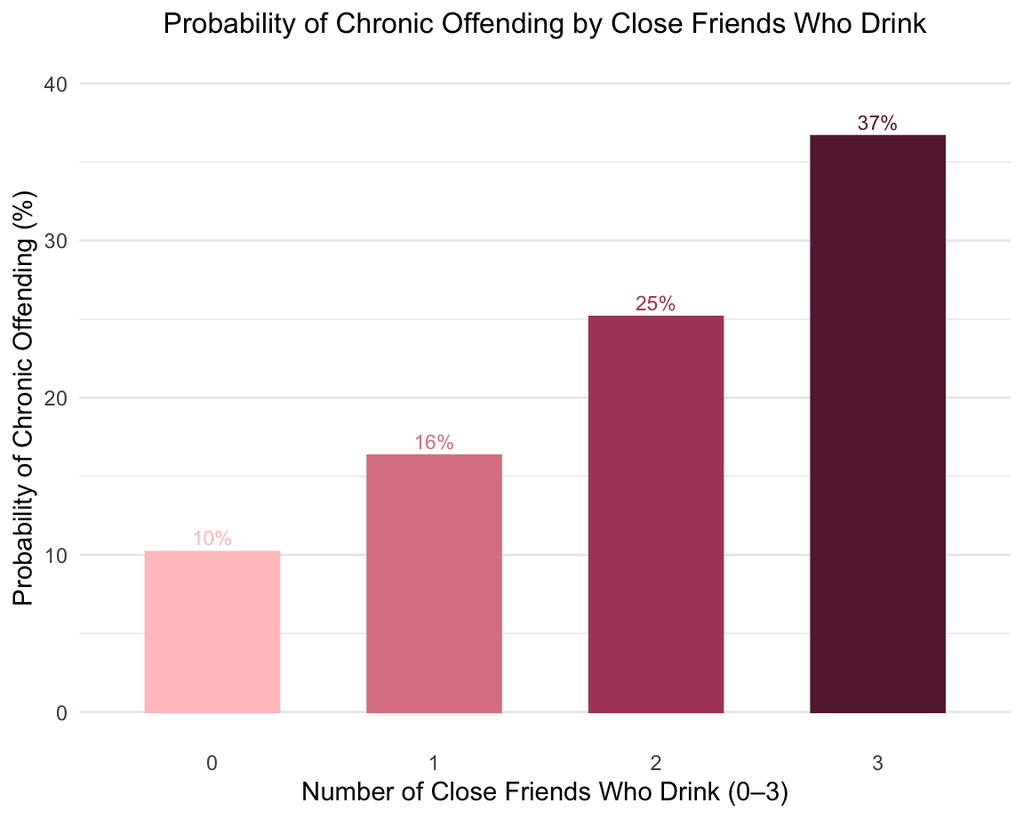

### **Friends Who Smoke Plot**

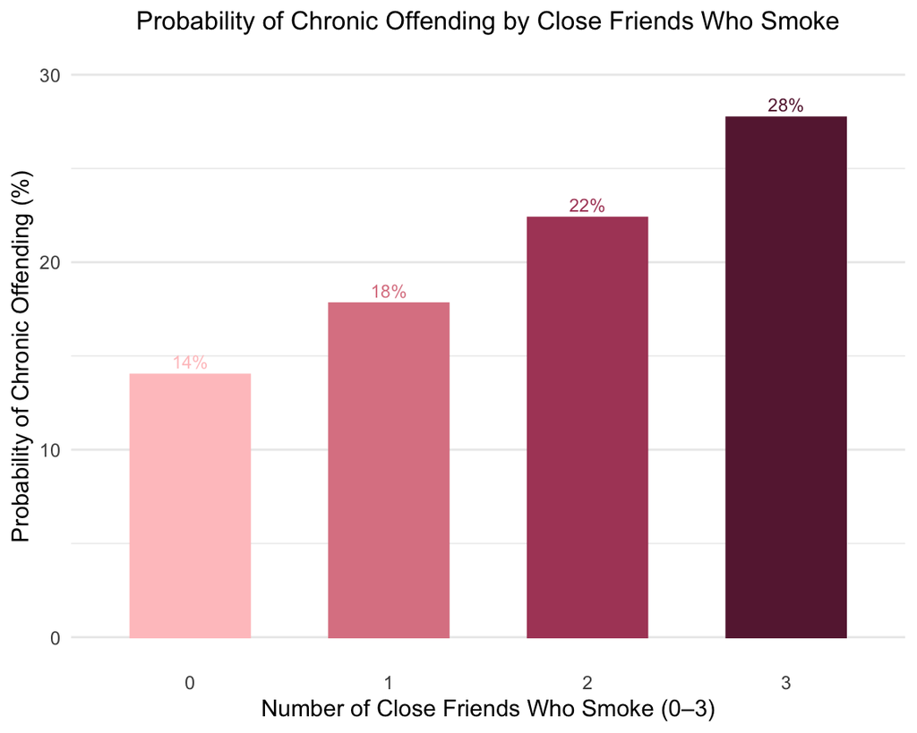

### **Friends Who Drink**

- Adolescents with no close friends who drink have an estimated 10% probability of chronic offending.
- This probability rises to 16% with one close friend who drinks. With two close friends who drink, the risk increases to 25%.
- Adolescents with three close friends who drink have the highest predicted probability at 37%, more than three times the risk compared to those with none.

The predicted probabilities are based on a binary logistic regression model, since `chronic` is a binary outcome. The baseline probability of 10% reflects the model’s estimate for someone with zero close friends who drink while all other factors (age, gender, maternal attachment, boredom, and friends who smoke) are held constant.

### **Friends Who Smoke**

- When no close friends smoke, the predicted probability of chronic offending is about 14%.
- This increases to 18% with one friend who smokes.
- With two friends who smoke, the probability rises to 22%.
- Adolescents with three close friends who smoke face a 28% probability of chronic offending, double the risk compared to those with none.

Again, the baseline probability (14% in this case) reflects the model’s estimate for a typical adolescent in the dataset (all other variables are held constant).

### **Exposure to Deviant Peers**

Peer influence plays a central role in theories of adolescent delinquency, which argue that young people are strongly shaped by the behaviors and norms of their close friends. Peer influence is particularly strong when peers approve of delinquency, share beliefs conducive to rule-breaking, and apply pressure to engage in deviant behavior (Agnew & Brezina, 2018). Consistent with this framework, the visualizations to the left show that greater exposure to deviant peers is associated with higher predicted probabilities of chronic juvenile offending.

# Control

### **Predicted Probability - Maternal Attachment Plot**

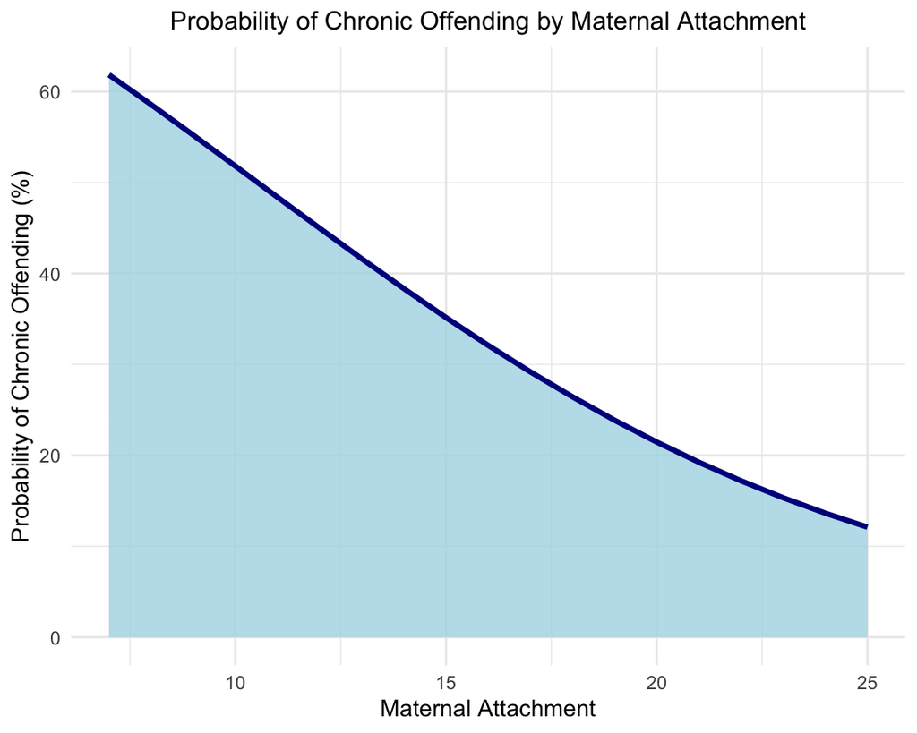

### **Control Theory**

Control theories of delinquency emphasize the importance of stake in conformity, arguing that adolescents who feel emotionally connected to conventional others have more to lose by engaging in delinquent behavior. Attachment to parental figures is a key component of this stake in conformity, as strong parent–child relationships create controls rooted in respect and approval. As Agnew (2018) notes, many adolescents avoid delinquency because they do not want to disappoint their parents or cause them to think poorly of them. In contrast, youth who experience weak or distant parental relationships may think that they have little to lose by engaging in rule-breaking behavior.

### **Maternal Attachment**

Consistent with control theory, the visualization to the left shows that higher levels of maternal attachment are associated with lower predicted probabilities of chronic juvenile offending. Maternal attachment is measured so that higher scores indicate greater emotional closeness to a mother or maternal figure. The downward trend shows that as maternal attachment increases, the likelihood of chronic offending steadily decreases. Youth with low attachment face the highest risk, while those with strong maternal attachment have substantially lower predicted probabilities of chronic offending.

# Strain

### **Predicted Probability - Boredom (Lowest 10% in Hobbies) Plot**

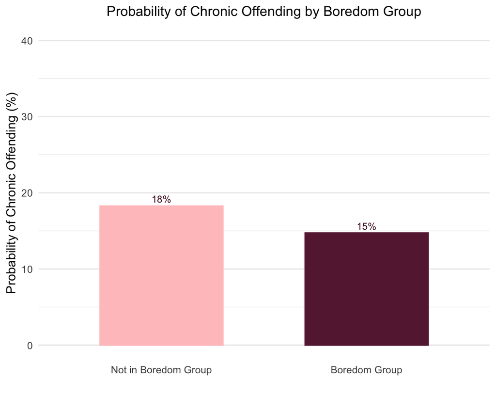

### **Strain Theory**

Strain theory suggests that frustrating circumstances can increase the likelihood of delinquency by producing negative emotions. According to this perspective, delinquent behavior can emerge as a response (Agnew & Brezina, 2018). One form of strain that is especially relevant to this project is boredom, or the inability to find excitement and stimulation through everyday activities. Agnew and Brezina argue that when adolescents struggle to meet their desire for excitement through conventional means, some may turn to delinquent behavior for this excitement. In this project, boredom represents a potential source of strain that could increase the risk of delinquency. However, as shown in this analysis, this relationship is not supported by the results.

The plot to the left compares the predicted probability of chronic offending for teens in the “boredom” group (lowest 10% in hobbies) versus everyone else (not in lowest 10% in hobbies). Contrary to my original strain-based hypothesis, adolescents flagged as bored actually have lower predicted probabilities of chronic offending in this model.

# Correlation Plots

### **Correlation Heatmap with Values**

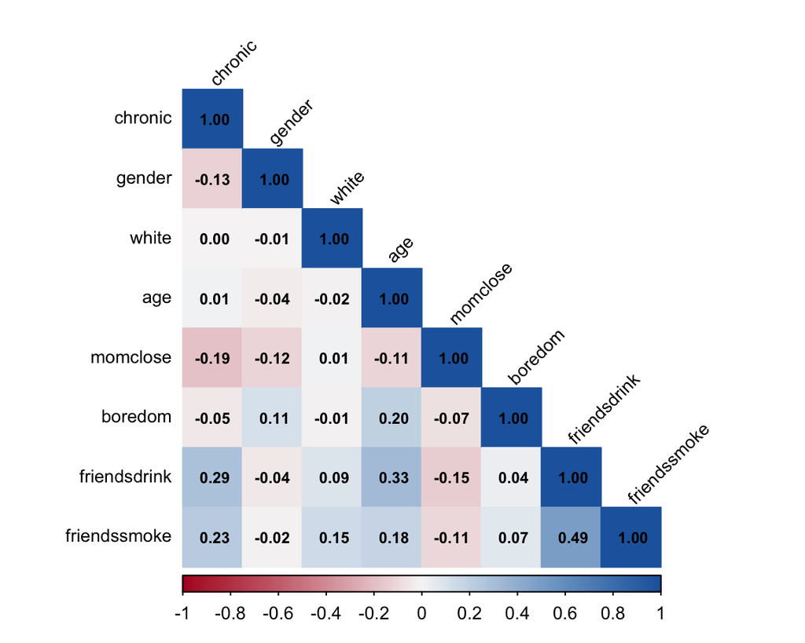

### **Correlation Bubble Map**

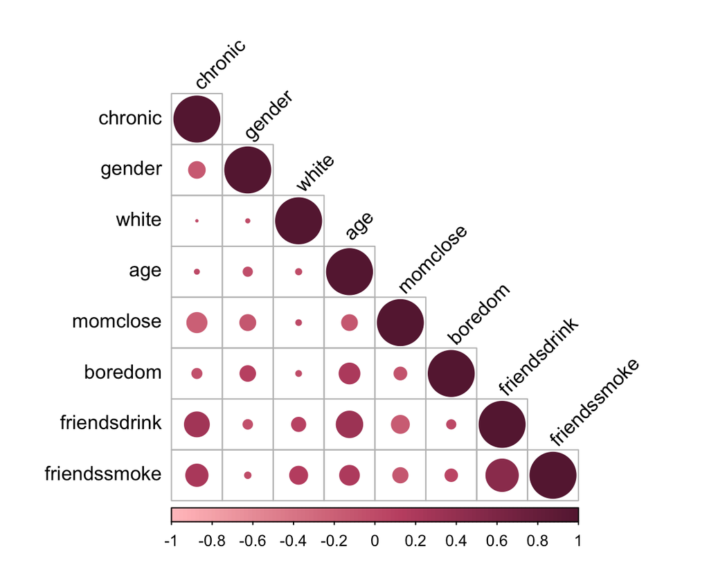

### **Interpretation**

The correlation heatmap and bubble plot provide an overview of how the key study variables relate to one another. Chronic offending is positively correlated with peer behaviors, specifically number of close friends who drink or smoke, reinforcing the importance of peer influence in delinquent behavior. Maternal attachment shows a negative association with chronic offending, suggesting that stronger emotional bonds with a maternal figure are linked to lower levels of persistent delinquency. Finally, boredom shows a negative association, suggesting that presence of strain in this context is not linked to chronic delinquency.

# Conclusion

### **Conclusion**

These updated analyses highlight the key factors that shape chronic juvenile offending. Peer influence remains the strongest predictor; having close friends who drink or smoke significantly increases the likelihood of chronic offending. Maternal attachment also plays a meaningful protective role, with higher closeness linked to lower odds of persistent delinquency.

Contrary to strain theory and my original hypothesis, adolescents in the “boredom group” were less likely to be chronic offenders. This suggests that strain, at least as measured here, may not operate in the way theory predicts.

*An important note:*

This project focuses on the three key theoretical predictors (maternal attachment, peer influence, and boredom), which all show significant associations with chronic juvenile offending at the 0.05 level in the regression model. Demographic variables were included as controls but were not the focus of the analysis. Because this project emphasizes visual communication, I chose not to include a full regression table and instead focused on interpreting the most relevant results.

### **Looking Forward**

Looking ahead, I would like to revisit the strain component of this project using a different measure. The boredom variable used here does not fully capture all types of strain that theory describes, such as goal blockage or chronic stressors (ex. financial hardship). Exploring alternative indicators could provide a clearer picture of how strain relates to chronic offending.

### **References**

- Agnew, R., & Brezina, T. (2018). Juvenile Delinquency: Causes and Control. Oxford University Press.
- University of North Carolina at Chapel Hill. Study design: National Longitudinal Study of Adolescent to Adult Health (Add Health). Carolina Population Center. https://addhealth.cpc.unc.edu/documentation/study-design/

Other useful sources included rdrr.io for info on [ggpredict](https://rdrr.io/cran/ggeffects/man/ggpredict.html) and the [colorspace](https://rdrr.io/cran/colorspace/) library.